# Explore and summarize Data Project

The reason I tried with volatile acidity divided by citric acid is that they are fairly inversely proportional, and when divided the resulting coefficient would be a “reinforced” version of the volatile acidity value (high values are even higher and low values are even lower).

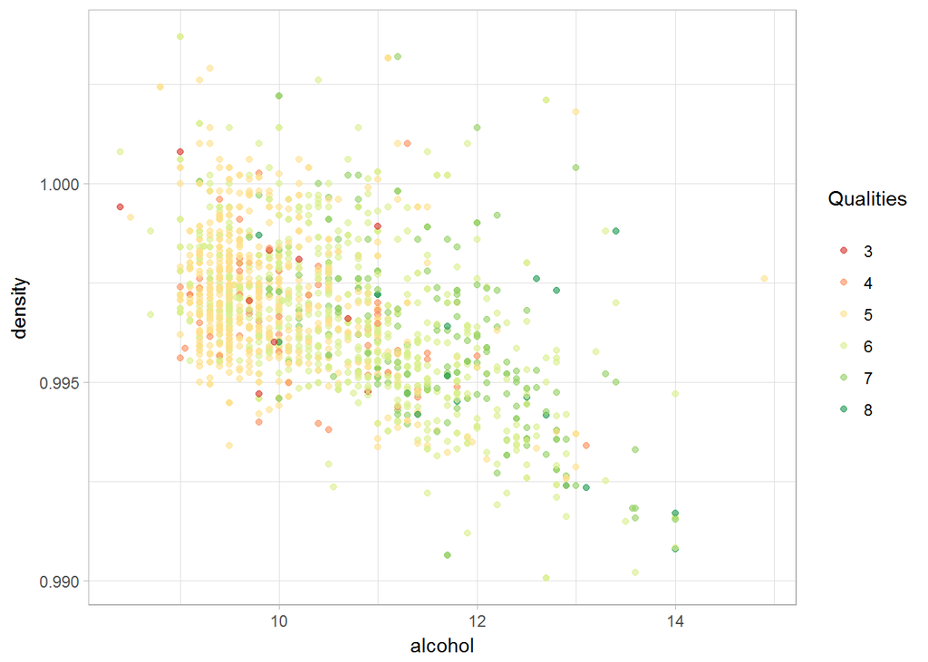

Alcohol and density also have one fairly high value for a negative pearson correlation coefficient, and since we already know that alcohol percentage tends to affect quality of the wine, it makes sense to plot this two variables. We can now confirm that lower densities tend to correspond to higher wine qualities.

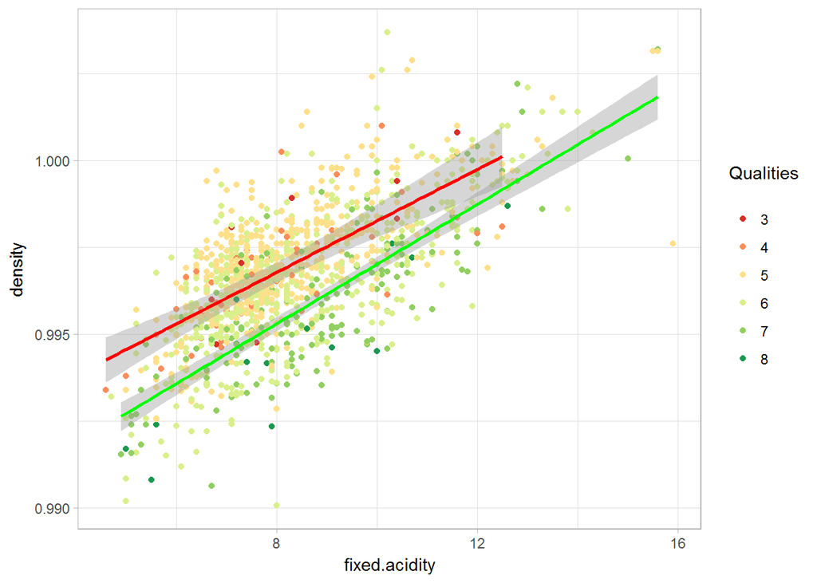

Since fixed acidity and density have the highest pearson correlation coefficient of all variables, it makes sense to want to look closer at the wine’s quality distribution.

In any case, different qualities can still take values near to both linear models, causing this plot to not be conclusive to differentiate qualities by varying this two attributes.

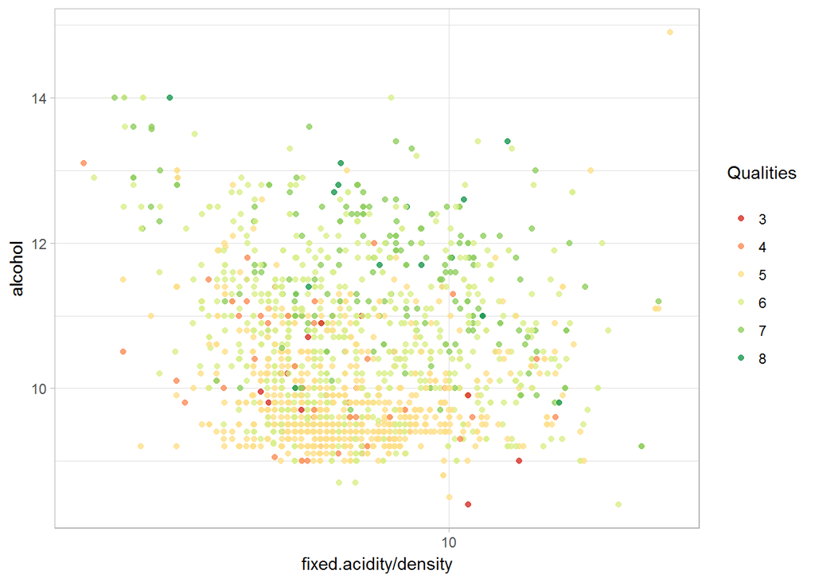

The resulting plot satisfies even less the objective of differentiating low, from mid and high quality wines. There is a small trend that shows how alcohol and fixed.acidity/density are inversely propotional, and how higher quality wines tend to have higher alcohol values for every point in the plot.

# Multivariate Analysis

### Talk about some of the relationships you observed in this part of the investigation. Were there features that strengthened each other in terms of looking at your feature(s) of interest?

Most of this section was about confirming what we already knew:

- Higher quality wines tend to have less density in part due to it’s inversely proportional relation with alcohol.
- Fixed acidity and density are fairly linear correlated, but neither of them drive a significant change in the quality of the wine.
- Almost all range of wine qualities can be found for very similar attribute values, even reaching a degree of considering quality to be a subjective variation.
- It is hard to see a clear division in the quality of the wines by varying two different attributes, then creating a new variable to better achieve this makes sense.

### Were there any interesting or surprising interactions between features?

- Volatile acidity divided by citric acid values do interact in a strange way, and I consider them to almost achieve to be the differentiation factor between wine qualities.

# Final Plots and Summary

### Plot One

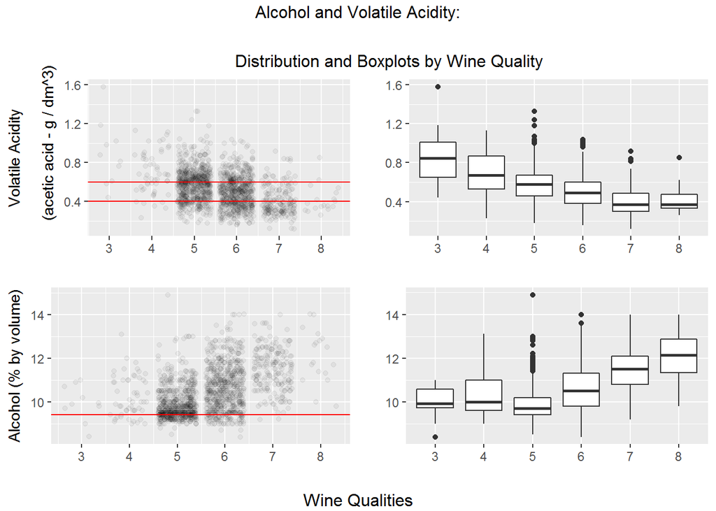

### Description One

This plot shows the distribution and boxplots for alcohol and volatile acidity values by wine qualities. The red lines in the plot indicate the mode for bot variables, making evident the bimodal nature of the volatile acidity distribution.

We can notice how the distribution of wine qualities is not even near to be constant for all qualities. This complicates the task of comparing attributes between them, cause not enought values of each quality are available for comparison.

Alcohol and volatile acidity are the most correlated attributes to wine qualities: This conclusion was made by comparing their pearson correlation coefficients with the rest of the variables, in which alcohol scored 0.48 and volatile acidity scored -0.39.

Neither of the pearson correlation coefficients for alcohol and volatile acidity are very high, but they let us notice a trend for higher quality wines to have higher alcohol percentage values and lower volatile acidity values. This can be verified by looking at the boxplots for each attribute.

### Plot Two

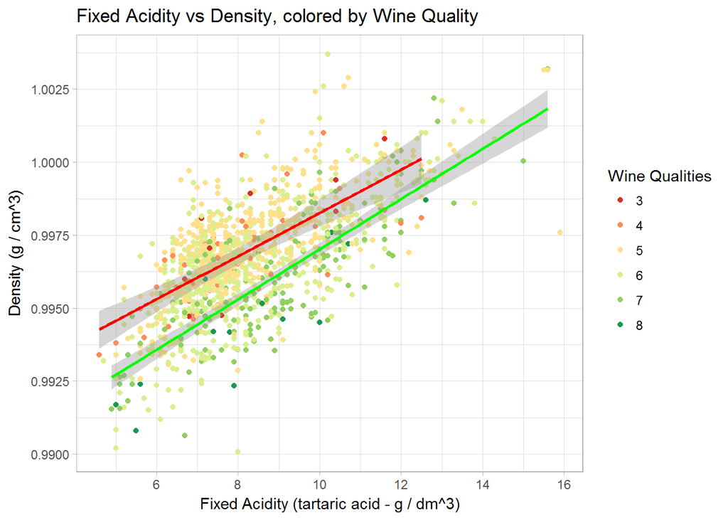

### Description Two

The plot two shows the fixed acidity vs density fairly linear relation (the highest pearson correlation coefficient between all variables with a score of 0.68) and how quality of the wines vary with them.

The linear models show how the is a clear trend for lower quality wines to have more density for any fixed acidity value, however this trend is not conclusive, as we can also see how a lot of different quality wines are spread trough all the plot and not follow their trends (especially medium quality wines).

As we saw in the first plot, many different quality wines share attribute values, now forcing us to seek some way to differentiate them: This is my main objective in the next plot.

### Plot Three

[output not shown]

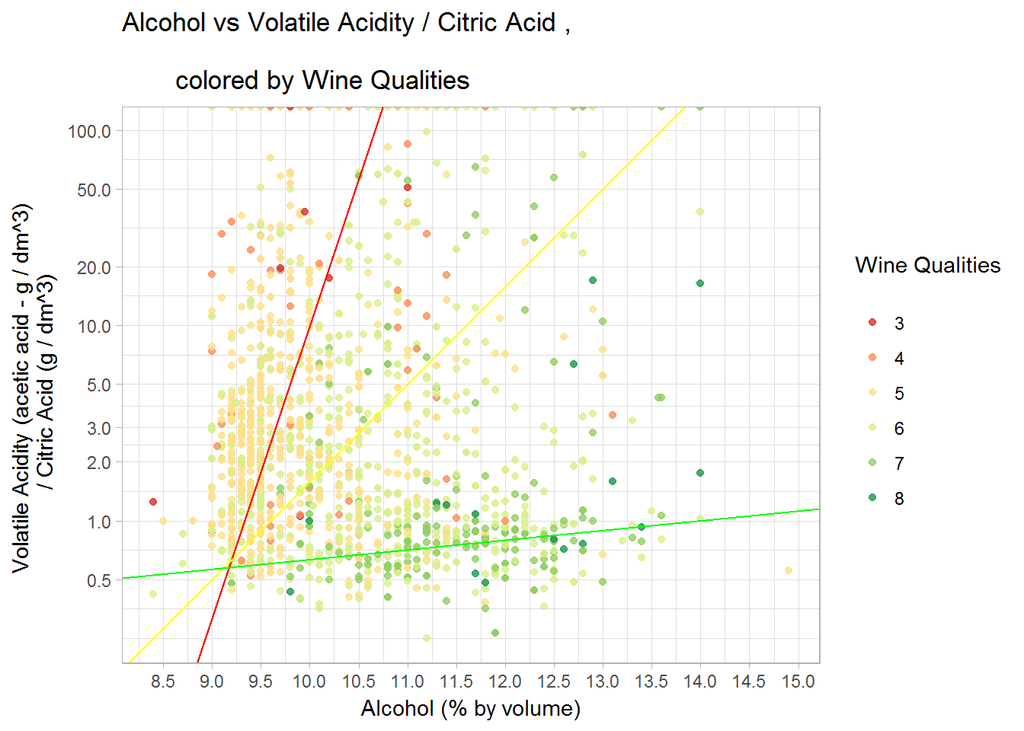

### Description Three

Ater trying different ways to differentiate wine qualities based on it’s attributes, I ended creating a new variable (volatile.acidity/citric.acid, this variable will be called from now on V1 to simplify referring to it).

Ploting V1 against alcohol fairly differentiates different wine qualities across the plot, as the plot shows the distribution of wines across this variables coloured by wine quality. To make trends easier to see, I plotted 3 linear models that signal the places in which we would expect most wines of different qualities (red for low, yellow for mid and green for high qualities) to fall near.

As we would also expect wines who dont follow any linear trend are present still, but this amount of wines is greatly reduced compared to other previous plots and also decreases as values for both variables increase.

# Reflection

The red wines data set contains information on 1599 wines across twelve variables from around 2009. I started by understanding the individual variables in the data set, and then I explored interesting questions and leads as I continued to make observations on plots. Eventually, I explored the quality of wines across many variables and identified trends to distinguish different wine qualities based in the other variables.

There was fairly clear trends between the alcohol percentage or volatile acidity and the quality of the wine but it was still surprising the big number of wines for which their qualities seem to be arbitrary and do not follow expected trends. Understanding how quality was related to this variables and this variables to the rest of them was key to discover some rare insights like the relation between V1 and alcohol or the lower density of higher quality wines.

The biggest problem I had when analysing the data was not constant distribution across all values for quality of the wines. It is hard to clearly identify trends that affect wine quality if you do not have data about the “extreme” cases, in which for example wines had much better quality or much poorer one according to their attributes.

Even when I think more equally distributed data would have been nice to have, I think it is important to face challenges like this, in which you have a real world problem and have to get the best out of it.